# Reproducible Science - penguins_assignment

## Q4

```r
library(palmerpenguins) #Begin by loading the necessary libraries for the task
library(ggplot2)
library(janitor)
library(dplyr)

#In the R code within the {r} I have specified to hide the messages and warnings, as this takes up a lot of space in the markdown document
```

For this assignment, we have to load in the raw data to use.

```r
PenguinsRaw <- read.csv("penguins_raw.csv") #Makes an object called PenguinsRaw, which consists of the data which the function read.csv has loaded into R
```

```r
head(PenguinsRaw) #view table, to check that data has indeed loaded
```

```
##   X.2 X.1 X studyName Sample.Number                             Species Region
## 1   1   1 1   PAL0708             1 Adelie Penguin (Pygoscelis adeliae) Anvers
## 2   2   2 2   PAL0708             2 Adelie Penguin (Pygoscelis adeliae) Anvers
## 3   3   3 3   PAL0708             3 Adelie Penguin (Pygoscelis adeliae) Anvers
## 4   4   4 4   PAL0708             4 Adelie Penguin (Pygoscelis adeliae) Anvers
## 5   5   5 5   PAL0708             5 Adelie Penguin (Pygoscelis adeliae) Anvers
## 6   6   6 6   PAL0708             6 Adelie Penguin (Pygoscelis adeliae) Anvers
##      Island              Stage Individual.ID Clutch.Completion   Date.Egg
## 1 Torgersen Adult, 1 Egg Stage          N1A1               Yes 2007-11-11
## 2 Torgersen Adult, 1 Egg Stage          N1A2               Yes 2007-11-11
## 3 Torgersen Adult, 1 Egg Stage          N2A1               Yes 2007-11-16
## 4 Torgersen Adult, 1 Egg Stage          N2A2               Yes 2007-11-16
## 5 Torgersen Adult, 1 Egg Stage          N3A1               Yes 2007-11-16
## 6 Torgersen Adult, 1 Egg Stage          N3A2               Yes 2007-11-16
##   Culmen.Length..mm. Culmen.Depth..mm. Flipper.Length..mm. Body.Mass..g.    Sex
## 1               39.1              18.7                 181          3750   MALE
## 2               39.5              17.4                 186          3800 FEMALE
## 3               40.3              18.0                 195          3250 FEMALE
## 4                 NA                NA                  NA            NA   <NA>
## 5               36.7              19.3                 193          3450 FEMALE
## 6               39.3              20.6                 190          3650   MALE
##   Delta.15.N..o.oo. Delta.13.C..o.oo.                       Comments
## 1                NA                NA Not enough blood for isotopes.
## 2           8.94956         -24.69454                           <NA>
## 3           8.36821         -25.33302                           <NA>
## 4                NA                NA             Adult not sampled.
## 5           8.76651         -25.32426                           <NA>
## 6           8.66496         -25.29805                           <NA>
```

```r
names(PenguinsRaw) #Views the column titles, so we can better understand what variables and data we are working with
```

```
##  [1] "X.2"                 "X.1"                 "X"
##  [4] "studyName"           "Sample.Number"       "Species"
##  [7] "Region"              "Island"              "Stage"
## [10] "Individual.ID"       "Clutch.Completion"   "Date.Egg"
## [13] "Culmen.Length..mm."  "Culmen.Depth..mm."   "Flipper.Length..mm."
## [16] "Body.Mass..g."       "Sex"                 "Delta.15.N..o.oo."
## [19] "Delta.13.C..o.oo."   "Comments"
```

```r
View(PenguinsRaw) #Load up the data full to see how complete it is. As we can see in this set of data, it contains a lot of missing information ("n/a")
```

```r
#Easiest way to "clean" it is by writing a function. This function called "cleaning", will clean column names, remove empty rows, remove columns called comment and delta
#This function is also in my github folder, for reproducibility

cleaning <- function(PenguinsRaw){
   PenguinsRaw %>%
     clean_names() %>%
     remove_empty(c("rows", "cols")) %>%
     select ( -starts_with("Delta")) %>%
     select ( -comments)
}

CleanPenguin <- cleaning(PenguinsRaw) #Now we make an object called CleanPenguin,which contains the raw data with the cleaning function applied to it


View(CleanPenguin) #Loads up the new object to view, and check that we have indeed made it
```

Now that we are working with ‘cleaned’ data, we can consider which statistical test to run on the data.

## Statistical Analysis

My chosen question is to examine what the mean effects of sex and body mass are on flipper length. I shall include all three species in the dataset to examine this question, in order to have a larger sample size.

I predict that heavier penguins, will have larger flippers to help them swim.

However, sexual dimorphism is common within biology and so to adjust for that variable, I’m also going to examine the effects of the interaction between sex and body mass on flipper length. To do this, I will use an ANCOVA.

Hypothesis (null): The interaction between sex and flipper length is not significant. The interaction between body mass and flipper length is not significant. The effect of sex is not dependent on body mass for flipper length (and vice versa)

```r
#Having viewed the CleanPenguin data, we can see there are still n/a values in some of the columns we are not interested in. Here we will remove those blank values so that they don't affect our analysis. We need the package dplyr in order to use the cleaning function described here

library(dplyr) #load package

TotalCleanPenguin <- CleanPenguin %>% filter(!is.na(sex) & !is.na(flipper_length_mm) & !is.na(body_mass_g))  #makes an object called TotalCleanpenguin which is a filtered version of the CleanPenguin data

View(TotalCleanPenguin)  #View this object to check the n/a's have been removed
```

```r
#Now we make an object called PenguinModel, which is a linear model of the effects of sex, body mass and their interaction on flipper length

PenguinModel <- lm (flipper_length_mm ~ sex + body_mass_g + sex*body_mass_g, TotalCleanPenguin)

summary(PenguinModel) #Summarise this to check it has worked
```

```
##
## Call:
## lm(formula = flipper_length_mm ~ sex + body_mass_g + sex * body_mass_g,
##     data = TotalCleanPenguin)
##
## Residuals:
##      Min       1Q   Median       3Q      Max
## -22.1736  -4.5905   0.6326   4.6430  15.0168
##
## Coefficients:
##                       Estimate Std. Error t value Pr(>|t|)
## (Intercept)          1.332e+02  3.042e+00  43.792   <2e-16 ***
## sexMALE             -1.397e+00  4.274e+00  -0.327    0.744
## body_mass_g          1.660e-02  7.763e-04  21.387   <2e-16 ***
## sexMALE:body_mass_g -6.177e-04  1.013e-03  -0.610    0.542
## ---
## Signif. codes:  0 '***' 0.001 '**' 0.01 '*' 0.05 '.' 0.1 ' ' 1
##
## Residual standard error: 6.623 on 329 degrees of freedom
## Multiple R-squared:  0.7787, Adjusted R-squared:  0.7767
## F-statistic: 385.9 on 3 and 329 DF,  p-value: < 2.2e-16
```

Now we have made our linear model, but to test it in ANOVA we must check that it answers certain assumptions of the test. These are: random sampling; normality of residuals for each independent variable; and the data should show homogeneity of variance.

We shall assume random sampling of the Palmer Penguins dataset for the purposes of this assignment.

However, to examine normality and homogeneity of variance, we can run diagnostic plots on the model to visually assess this.

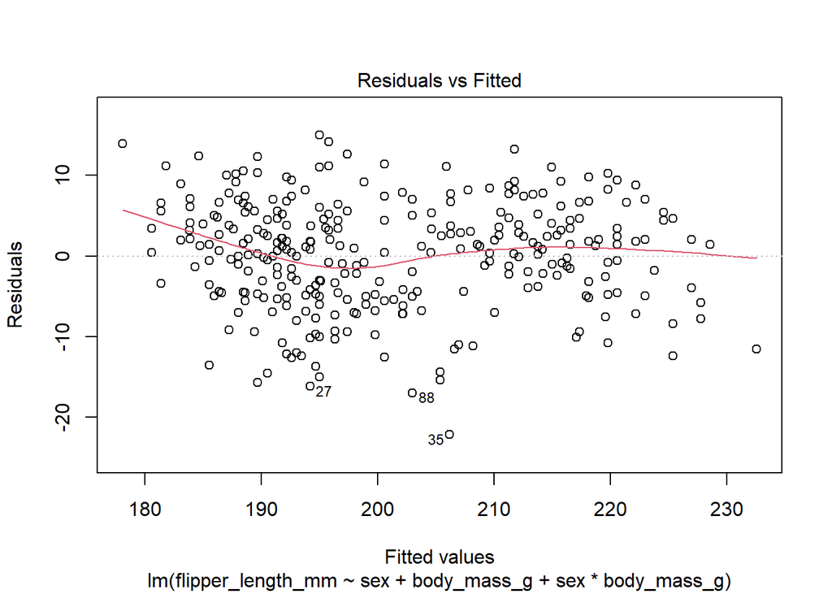

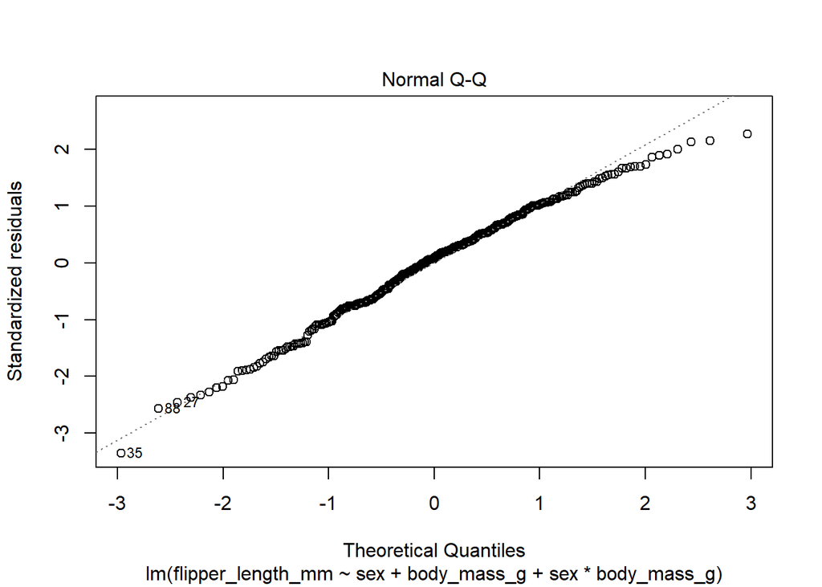

```r
plot(PenguinModel, which = 1:2) #Runs standard diagnostic models, selecting only the first two from the four that can be produced, as these examine homogenity and normality respectively
```

From a visual assessment, the assumptions seem to be met. There is some deviation from the line on the top-end tail of the q-q plot but this is very small. The points in the residuals-fitted plot do seem equally distributed, supporting our assumption of homogeniety of variance. There are very few outliers.

This means we can continue on to run an ANOVA test in r (but since we are using a factor (sex) and a continuous variable, this is what is statistically termed an ANCOVA)

```r
PenguinAnova <- anova(PenguinModel, test = "F") #Runs the model, and puts it in an object called PenguinAnova
PenguinAnova #To view the ANOVA table
```

```
## Analysis of Variance Table
##
## Response: flipper_length_mm
##                  Df Sum Sq Mean Sq   F value Pr(>F)
## sex               1   4246    4246   96.8066 <2e-16 ***
## body_mass_g       1  46524   46524 1060.6110 <2e-16 ***
## sex:body_mass_g   1     16      16    0.3718 0.5425
## Residuals       329  14432      44
## ---
## Signif. codes:  0 '***' 0.001 '**' 0.01 '*' 0.05 '.' 0.1 ' ' 1
```

An ANCOVA was performed by the code, to analyse the effect of Sex , and Body Mass on the Flipper Length.

The analysis revealed that there was not a statistically significant interaction between the effects of Sex and Body Mass (p = 0.5425).

Simple main effects analysis showed that Sex did have a statistically significant effect on Flipper Length (p = <2e-16, i.e. very close to zero) .

Simple main effects analysis showed that Body Mass did have a statistically significant effect on Flipper Length (p = <2e-16).

## Plotting the figure

Now we shall plot this as a scatterplot with the model overlaid in order to visually assess interaction.

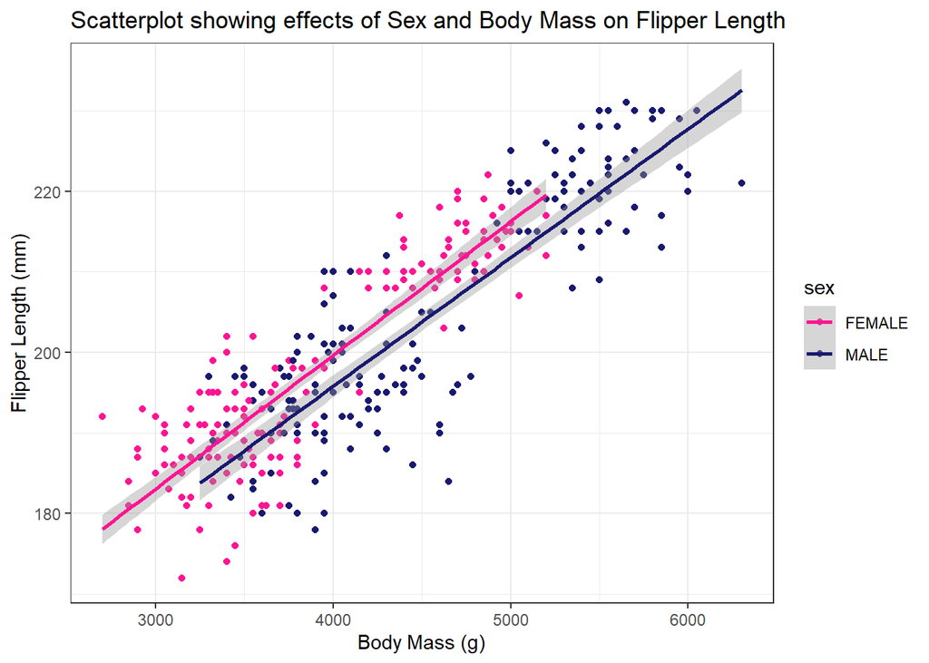

```r
#This creates an object called PlotModel, which is a ggplot of our interaction. It is also coloured to distinguish between the two versions of the factor sex (male and female), and titled appropriately

PlotModel<- ggplot(TotalCleanPenguin, aes(x = body_mass_g, y = flipper_length_mm, colour = sex)) +
  geom_point() +  #Plots the data points
  geom_smooth(method = 'lm')+
labs(x = "Body Mass (g)",
       y = "Flipper Length (mm)",
     title = "Scatterplot showing effects of Sex and Body Mass on Flipper Length ")+ #adds labels
  scale_x_continuous() +
  scale_color_manual(values = c("deeppink1","midnightblue"))+ #adds desired colours
  theme_bw() # makes background white to see the lines more clearly, so that it is more accessible

#The colours "deeppink1" and "midnightblue" were chosen both as colours for the variables female and male, because these two choices are colourblind friendly for Tritanopia, Protanopia and Deuteranopia. While perhaps un-biological, I think they are intuitive.


PlotModel #to view the plot of model 4
```

We can see that flipper length increases with body mass regardless of sex, though there is a significant difference between sexes in flipper length. However, we can see that the interaction between sex and body mass is not statistically significant.

This suggests that heavier penguins will indeed have longer flippers. Perhaps, where body mass or flipper length data is missing, once could estimate these values from linear models.